# DASC 5302 - Chapter 5

DASC 5302

Chapter 5

Dr. Lei Jin

# Chapter 5: Nonlinear Models

## Part II: Multivariate Adaptive Regression Splines (MARS)

**Multivariate Adaptive Regression Splines (MARS)** is a flexible and powerful statistical modeling technique widely used in **data mining, machine learning, and predictive analytics**. It is primarily designed for **regression problems**, but can also be adapted for **classification**. MARS extends traditional linear regression by relaxing the assumption that the relationship between the response variable and predictors follows a single, fixed functional form. Instead, it uses a **nonparametric, data-driven approach** that allows the model structure to be determined adaptively from the observed data.

Unlike standard linear regression, which assumes a global linear relationship between the response and predictors, MARS constructs a model using **piecewise linear functions** defined over different regions of the predictor space. These regions are determined by **knots** (also called **cutpoints**), which identify locations where the relationship between a predictor and the response may change. By combining multiple piecewise linear functions, MARS can effectively capture **nonlinear relationships, changes in slopes, and interactions among predictor variables** that may not be adequately represented by traditional linear models.

The key components of MARS are **basis functions**, which are typically constructed using pairs of piecewise linear functions known as **hinge functions**. Each pair represents the behavior of a predictor on either side of a selected knot. MARS automatically selects the important predictors, knot locations, and basis functions through a two-stage modeling procedure:

1. **Forward selection:** The algorithm progressively adds basis functions and potential interactions to improve model fit.
2. **Backward pruning:** The algorithm removes unnecessary basis functions to reduce model complexity and avoid overfitting, often using the **Generalized Cross-Validation (GCV)** criterion.

This adaptive procedure allows MARS to balance **predictive accuracy, model flexibility, and interpretability**. Unlike many other nonlinear modeling techniques, MARS produces an explicit mathematical model that can be examined to understand how predictors influence the response.

One of the main advantages of **MARS** is its ability to capture **nonlinear relationships** without requiring a predefined functional form. It automatically identifies important predictors, selects appropriate knot locations, and constructs basis functions based on the observed data. MARS can also model **interactions among predictor variables**, allowing it to represent more complex relationships. In addition, the resulting model is relatively **interpretable**, since it consists of explicit piecewise linear functions that describe how predictors influence the response. By combining flexibility with automatic variable selection and model simplification, MARS provides a useful balance between **predictive accuracy, model complexity, and interpretability**.

## Mathematical Formulation of MARS

The general form of a **Multivariate Adaptive Regression Splines (MARS)** model is

$$ { \hat{y} = \beta_0 + \sum_{m=1}^{M} \beta_m B_m(\mathbf{x}) } $$

where:

- $\hat{y}$ is the **predicted response**.
- $\beta_0$ is the **intercept term**.
- $\beta_m$ are the **regression coefficients** estimated from the data.
- $B_m(\mathbf{x})$ are the **basis functions** constructed from the predictor variables.
- $M$ is the **number of basis functions** included in the final model.
- $\mathbf{x}=(x_1,x_2,\ldots,x_p)^T$ represents the vector of predictor variables.

Unlike ordinary linear regression, which uses the original predictors directly, MARS constructs **basis functions** that allow the relationship between predictors and the response to change across different regions of the predictor space.

### Hinge Functions

The fundamental building blocks of MARS are **hinge functions**, also called **piecewise linear spline functions**.

For a predictor $x$ and a knot $t$, a pair of hinge functions is defined as

$$ { h_1(x,t)=\max(0,x-t), \qquad h_2(x,t)=\max(0,t-x). } $$

Equivalently,

$$ h_1(x,t)= \begin{cases} 0, & x\leq t,\\ x-t, & x>t, \end{cases} $$

and

$$ h_2(x,t)= \begin{cases} t-x, & x<t,\\ 0, & x\geq t. \end{cases} $$

Here, $t$ represents a **knot (cutpoint)** at which the slope of the function can change.

The first hinge function is zero when $x\leq t$ and increases linearly when $x>t$. The second is zero when $x\geq t$ and increases linearly as $x$ decreases below $t$. By combining these functions, MARS can construct **continuous piecewise linear relationships with different slopes on either side of a knot**, allowing it to capture nonlinear patterns in the data.

### Interaction Terms

In addition to modeling nonlinear effects of individual predictors, MARS can incorporate **interactions among predictor variables**.

Interaction basis functions are constructed by multiplying hinge functions involving different predictors. For example, a two-variable interaction can be written as

$$ { B_m(\mathbf{x}) = \max(0,x_1-t_1) \max(0,x_2-t_2). } $$

where $t_1$ and $t_2$ are the knots associated with predictors $x_1$ and $x_2$, respectively.

This interaction term is nonzero only when **both $x_1>t_1$ and $x_2>t_2$**. It allows the effect of one predictor on the response to depend on the value of another predictor. More generally, MARS basis functions may consist of individual hinge functions or products of several hinge functions, depending on the allowed interaction degree. MARS builds a flexible predictive model by combining **piecewise linear basis functions** and their interactions. The locations of knots, selection of predictors, and inclusion of interaction terms are determined adaptively from the data, enabling MARS to model complex nonlinear relationships while maintaining a relatively interpretable mathematical structure.

## How MARS Works: An Illustrative Example

To understand how MARS works, consider a simple regression problem involving one predictor $X$ and a response variable $Y$. Rather than fitting a single straight line to all observations, MARS searches for **knots (cutpoints)** where the relationship between $X$ and $Y$ may change. It evaluates candidate knots and adds basis functions that improve the model fit. For illustration, suppose a knot is selected at $x_0=1.3$. This divides the predictor space into two regions, allowing the regression relationship to have **different slopes on either side of the knot**.

### Example: A Knot at $x_0=1.3$

Consider the hinge function

$$ h(x-1.3)=\max(0,x-1.3). $$

It can be expressed as

$$ h(x-1.3)= \begin{cases} 0, & x<1.3,\\ x-1.3, & x\geq1.3. \end{cases} $$

This function is zero to the left of the knot and increases linearly to the right.

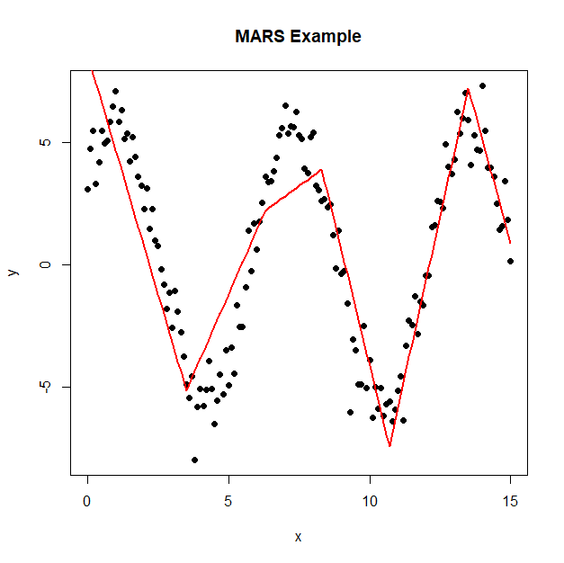

A simple MARS model with one knot can be written as

$$ { \hat{y}=\beta_0+ \beta_1\max(0,1.3-x) +\beta_2\max(0,x-1.3). } $$

Equivalently,

$$ \hat{y}= \begin{cases} \beta_0+\beta_1(1.3-x), & x<1.3,\\ \beta_0+\beta_2(x-1.3), & x\geq1.3. \end{cases} $$

**Interpretation:**

- For $x<1.3$, the regression line has slope $-\beta_1$.
- For $x>1.3$, the regression line has slope $\beta_2$.
- At $x=1.3$, both expressions give $\hat{y}=\beta_0$, ensuring that the fitted function is **continuous at the knot**.

Thus, MARS can model a **change in slope at $x=1.3$** while maintaining a continuous fitted regression function.

In practice, MARS automatically searches for suitable knot locations and may include several knots to capture more complex nonlinear patterns. The algorithm uses **forward selection** to construct candidate basis functions, followed by **backward pruning** to remove unnecessary terms and reduce overfitting.

## Implementing MARS in R: The `earth` Package

In R, the **`earth`** package provides an implementation of MARS for regression and classification problems. The `earth()` function automatically selects predictors, constructs hinge functions, identifies knot locations, and simplifies the resulting model. The `earth()` function uses **Generalized Cross-Validation (GCV)** by default for model pruning, helping balance goodness-of-fit and model complexity. Unlike the illustrative example with a fixed knot at $x=1.3$, the `earth()` function automatically determines appropriate knot locations from the training data.

R pakcage "earth"

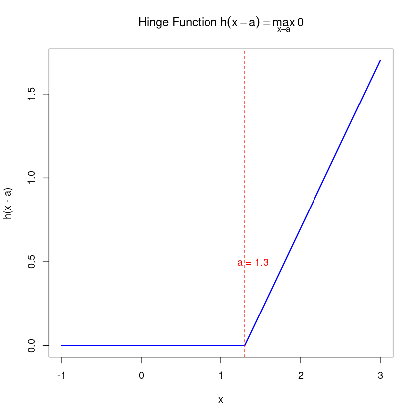

```r
# Define hinge function
hinge = function(x, a) {
  pmax(0, x - a)
}

# Set parameters
a = 1.3
x = seq(-1, 3, by = 0.1)
y = hinge(x, a)

# Plot the hinge function
plot(x, y, type = "l", lwd = 2, col = "blue",
     main = expression(paste("Hinge Function ", h(x - a) == max(0, x - a))),
     xlab = "x", ylab = "h(x - a)")
abline(v = a, col = "red", lty = 2)  # indicate the knot
text(a + 0.1, 0.5, paste("a =", a), col = "red")
```

```r
#MARS
library(earth)
```

Example: Simulates a nonlinear relationship, fits a MARS model using the earth package, and visualizes the predictions.

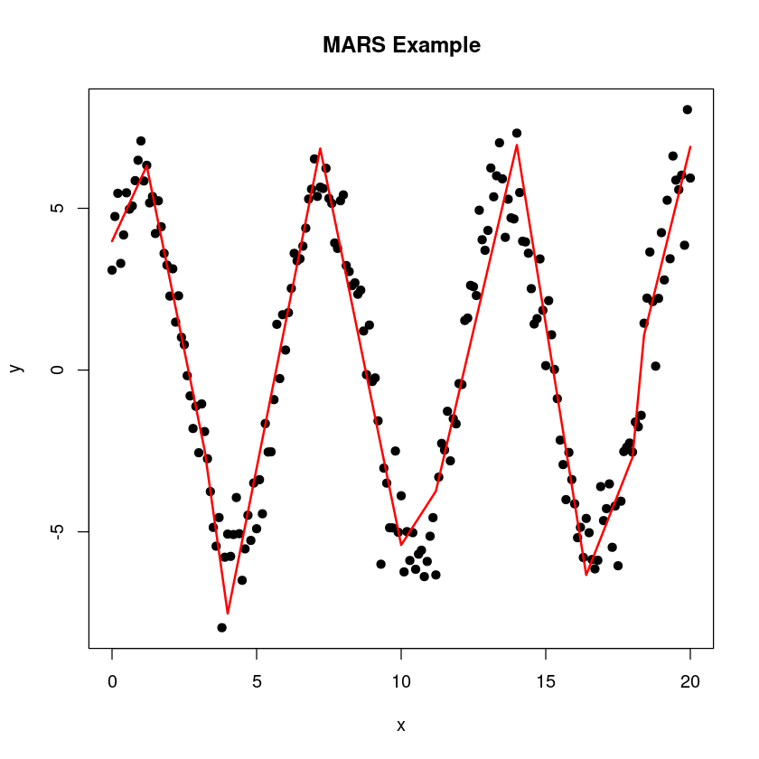

```r
#Simulate some example data
set.seed(372)
x = seq(0, 20, by = 0.1)
y = 5 * sin(x) + 3*cos(x) + rnorm(length(x))

#Create a data frame
dat = data.frame(x = x, y = y)

#Fit a MARS model
mars_fit = earth(y ~ x, data = dat)

#Summary of the fit
#summary(mars_fit)

#Make predictions using the MARS model
new_data = data.frame(x = seq(0, 20, by = 0.1))
predictions = predict(mars_fit, newdata = new_data)

#Plot the original data and MARS predictions
plot(x, y, main = "MARS Example", xlab = "x", ylab = "y", pch = 19)
lines(new_data$x, predictions, col = "red", lwd = 2)
```

1.28051433736475

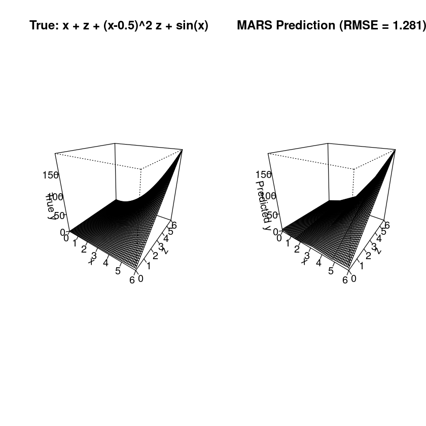

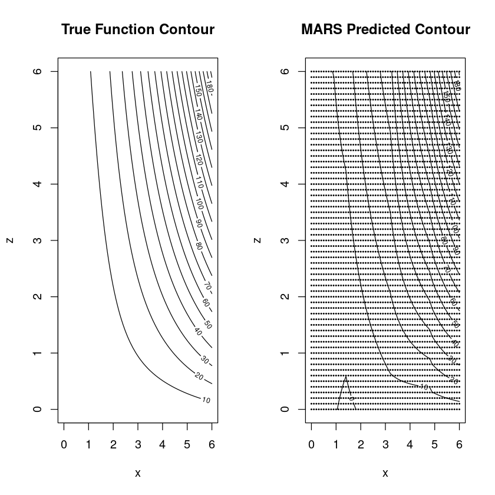

```r
# --- Simulate data: y = x + z + (x-0.5)^2 * z + sin(x) + noise ---
set.seed(372)

# Predictor sequences and grid
x_seq = seq(0, 6, by = 0.1)
z_seq = seq(0, 6, by = 0.1)
grid = expand.grid(x = x_seq, z = z_seq)

# True surface and noisy response
f_true = with(grid, x + z + (x - 0.5)^2 * z + sin(x))
y = f_true + rnorm(nrow(grid), sd = 0.3)

# Data frame for modeling
dat = data.frame(x = grid$x, z = grid$z, y = y)

# --- Fit MARS with interactions (degree = 2 allows x:z terms) ---
# install.packages("earth")  # if needed
library(earth)
mars_fit = earth(y ~ x + z, data = dat, degree = 2)

# --- Predictions on the same grid ---
pred_vec = predict(mars_fit, newdata = grid)

# Reshape to matrices for plotting
nx = length(x_seq); nz = length(z_seq)
true_mat = matrix(f_true, nrow = nx, ncol = nz, byrow = FALSE)
pred_mat = matrix(pred_vec, nrow = nx, ncol = nz, byrow = FALSE)

# RMSE against the true surface
rmse = sqrt(mean((pred_vec - f_true)^2))
rmse

# --- 3D surfaces: True vs Predicted ---
op = par(mfrow = c(1, 2))
persp(x_seq, z_seq, true_mat,
      theta = 35, phi = 25,
      xlab = "x", ylab = "z", zlab = "True y",
      main = "True: x + z + (x-0.5)^2 z + sin(x)",
      ticktype = "detailed")
persp(x_seq, z_seq, pred_mat,
      theta = 35, phi = 25,
      xlab = "x", ylab = "z", zlab = "Predicted y",
      main = paste0("MARS Prediction (RMSE = ", round(rmse, 3), ")"),
      ticktype = "detailed")

# --- Contour comparison with training points overlay ---
par(mfrow = c(1, 2))
contour(x_seq, z_seq, true_mat, nlevels = 15,
        xlab = "x", ylab = "z",
        main = "True Function Contour")
contour(x_seq, z_seq, pred_mat, nlevels = 15,
        xlab = "x", ylab = "z",
        main = "MARS Predicted Contour")
points(dat$x, dat$z, pch = 20, cex = 0.3)
par(op)
```

Example: Build a predictive model using MARS to predict "medv" using all other features, using Boston data. Please split the data into traning set and testing set. Build the model on the traing set and test the model using the testing set.

```r
#Use Mars to build a model to predict "house price" using othe varialbes in the data.

# Use the boston housing data
# Build a predictive model using MARS to predict "medv" using all other features
library(MASS)
library(tidyverse)
library(caret)
library(earth)
```

```r
#There are 14 varables:  medv is the price of house (response)
#https://search.r-project.org/CRAN/refmans/ISLR2/html/Boston.html
data(Boston)
str(Boston)

set.seed(252)

#Transformed data
#Boston.dat = Boston %>%  mutate_all(scale.fun)
#Split the data
#Split the data into training and testing set according to medv

index = createDataPartition(Boston$medv, p = 0.8, list = FALSE)
train.dat = Boston[index,]
test.dat =   Boston[-index,]

#No scaling
```

```
'data.frame':	506 obs. of  14 variables:
 $ crim   : num  0.00632 0.02731 0.02729 0.03237 0.06905 ...
 $ zn     : num  18 0 0 0 0 0 12.5 12.5 12.5 12.5 ...
 $ indus  : num  2.31 7.07 7.07 2.18 2.18 2.18 7.87 7.87 7.87 7.87 ...
 $ chas   : int  0 0 0 0 0 0 0 0 0 0 ...
 $ nox    : num  0.538 0.469 0.469 0.458 0.458 0.458 0.524 0.524 0.524 0.524 ...
 $ rm     : num  6.58 6.42 7.18 7 7.15 ...
 $ age    : num  65.2 78.9 61.1 45.8 54.2 58.7 66.6 96.1 100 85.9 ...
 $ dis    : num  4.09 4.97 4.97 6.06 6.06 ...
 $ rad    : int  1 2 2 3 3 3 5 5 5 5 ...
 $ tax    : num  296 242 242 222 222 222 311 311 311 311 ...
 $ ptratio: num  15.3 17.8 17.8 18.7 18.7 18.7 15.2 15.2 15.2 15.2 ...
 $ black  : num  397 397 393 395 397 ...
 $ lstat  : num  4.98 9.14 4.03 2.94 5.33 ...
 $ medv   : num  24 21.6 34.7 33.4 36.2 28.7 22.9 27.1 16.5 18.9 ...
```

```r
#Fit a MARS model
#earth: fit a MARS model

mars.fit = earth(medv ~ ., data = train.dat)
summary(mars.fit)
```

```
Call: earth(formula=medv~., data=train.dat)

                coefficients
(Intercept)       -26.251808
h(crim-3.56868)    11.823026
h(crim-3.8497)    -12.687553
h(crim-11.8123)     0.795316
h(indus-21.89)     -0.825814
h(nox-0.488)      -21.136093
h(rm-6.417)         7.814934
h(rm-7.923)        -7.857504
h(dis-1.4165)      61.261024
h(2.3158-dis)      64.405616
h(dis-2.3158)     -61.928928
h(243-tax)          0.088397
h(14.7-ptratio)     1.513448
h(ptratio-14.7)    -0.695848
h(392.69-black)    -0.004811
h(black-392.69)    -0.348244
h(5.98-lstat)       2.756739
h(lstat-5.98)      -0.456408

Selected 18 of 23 terms, and 9 of 13 predictors
Termination condition: Reached nk 27
Importance: rm, lstat, dis, ptratio, nox, crim, tax, indus, black, ...
Number of terms at each degree of interaction: 1 17 (additive model)
GCV 12.40884    RSS 4219.129    GRSq 0.8554116    RSq 0.8786144
```

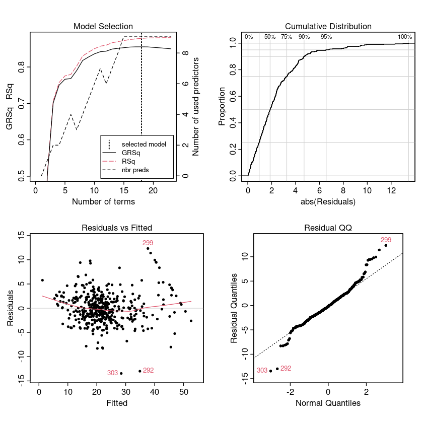

```r
#Model visulization : the effect of each variable
## Model diagnostics plot
plot(mars.fit, legend.pos = "bottomright", caption = "")
```

```
 plotmo grid:    crim zn indus chas   nox    rm  age    dis rad tax ptratio
               0.2498  0  9.69    0 0.538 6.208 77.8 3.1323   5 330    19.1
  black lstat
 391.83 11.34
```

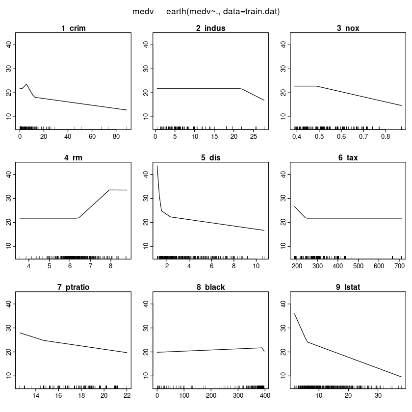

```r
## plot each fitted functions holding other terms at their medians
#To see the effect of each variable, when holding other variables
plotmo(mars.fit, nrug = -1)

#For example: when nox is above 0.488,  the effect of nox on medv is "-21.136093" per unit change of nox,
#when holding other variables fixed.
```

Use "train" function to select the best hyper paramters for MARS.

There are two crucial tuning hyper parameters: the maximum degree of interactions, and the number of terms in the final model. To determine the best combination of these hyperparameters, we need a grid search to minimize prediction error.

Suppose that we would like to use repeated cv, with k=6 and repeats = 5

```r
# Model training using the caret package : train function
set.seed(295)

#Cross validation
#cv.control =  trainControl(method = "cv",
#                           number = 6)

cv.control =  trainControl(## 10-fold CV
                           method = "repeatedcv",
                           number = 6,
                           ## repeated ten times
                           repeats = 5)

#
# create a tuning grid
# degree:  the maximum degree of interactions ;  nprune: the number of terms in the final model
hyper_grid <- expand.grid(
  degree = 1:2,
  nprune = c(10, 13,  15, 17, 20)
)
#10

#to find the optimal tuning parameters
mars.fit = train(medv ~ ., data = train.dat,  method = "earth",
                   trControl = cv.control,
                   trace = FALSE,
                   tuneGrid = hyper_grid
               #    preProc = c("center", "scale"),
               #    maxit = 500
                )

summary(mars.fit)
```

```
Call: earth(x=matrix[407,13], y=c(21.6,34.7,33...), keepxy=TRUE, trace=FALSE,
            degree=2, nprune=20)

                              coefficients
(Intercept)                       28.84355
h(6.417-rm)                       -4.91097
h(rm-6.417)                        9.80525
h(age-18.8)                       -0.05876
h(1.4165-dis)                    718.14923
h(dis-1.4165)                     -0.70029
h(224-tax)                         0.11294
h(lstat-5.98)                     -0.65931
h(1.4165-dis) * black             -1.75344
h(0.32543-crim) * h(tax-224)      -0.02986
h(crim-0.32543) * h(tax-224)      -0.00019
h(0.693-nox) * h(lstat-5.98)       2.57214
h(nox-0.693) * h(lstat-5.98)       1.38831
h(5.757-rm) * h(age-18.8)          0.12381
h(rm-6.417) * h(ptratio-18.4)     -6.11892
h(rm-6.417) * h(18.4-ptratio)      0.68116
h(284-tax) * h(5.98-lstat)         0.03125
h(tax-284) * h(5.98-lstat)         0.02043

Selected 18 of 26 terms, and 9 of 13 predictors (nprune=20)
Termination condition: Reached nk 27
Importance: rm, lstat, dis, ptratio, tax, nox, black, age, crim, zn-unused, ...
Number of terms at each degree of interaction: 1 7 10
GCV 8.631267    RSS 2802.135    GRSq 0.8994281    RSq 0.9193817
```

```r
mars.fit

#The best tuning parameters
#the best tuning parameters
mars.fit$bestTune
```

```
Multivariate Adaptive Regression Spline

407 samples
 13 predictor

No pre-processing
Resampling: Cross-Validated (6 fold, repeated 5 times)
Summary of sample sizes: 339, 340, 338, 340, 339, 339, ...
Resampling results across tuning parameters:

  degree  nprune  RMSE      Rsquared   MAE
  1       10      4.060558  0.8063098  2.806580
  1       13      3.917563  0.8207846  2.717696
  1       15      3.909852  0.8225662  2.727295
  1       17      3.913864  0.8222379  2.741432
  1       20      3.919375  0.8213476  2.734552
  2       10      3.934411  0.8243219  2.763964
  2       13      3.959164  0.8220021  2.674245
  2       15      3.966938  0.8218680  2.648816
  2       17      3.905765  0.8263173  2.615104
  2       20      3.878430  0.8281977  2.586831

RMSE was used to select the optimal model using the smallest value.
The final values used for the model were nprune = 20 and degree = 2.
```

A data.frame: 1 × 2

|  | nprune <dbl> | degree <int> |
| --- | --- | --- |
| 10 | 20 | 2 |

```
 plotmo grid:    crim zn indus chas   nox    rm  age    dis rad tax ptratio
               0.2498  0  9.69    0 0.538 6.208 77.8 3.1323   5 330    19.1
  black lstat
 391.83 11.34
```

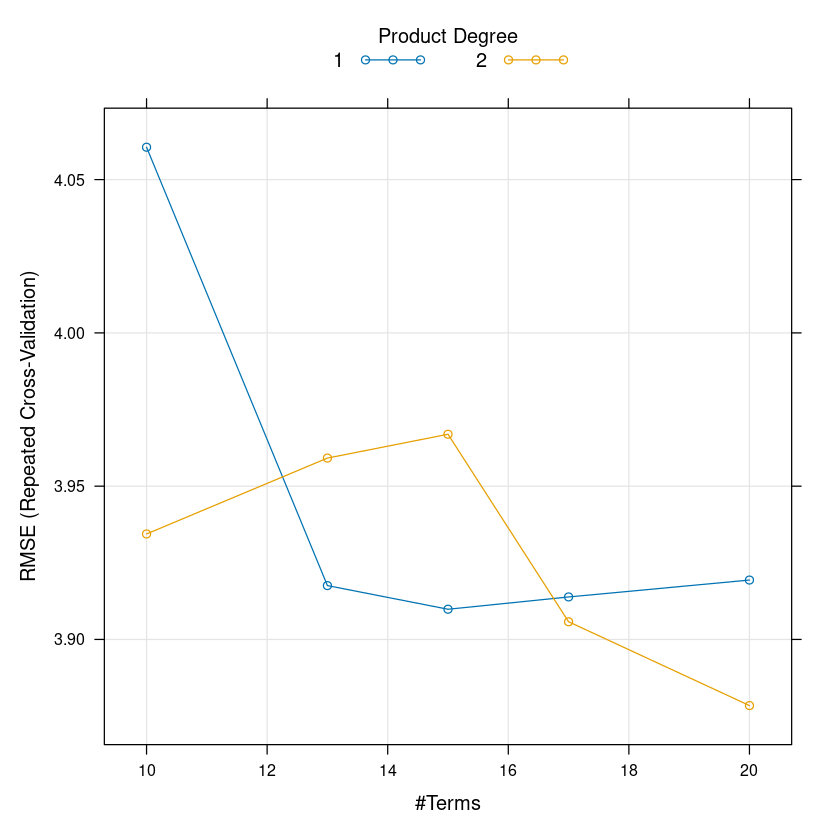

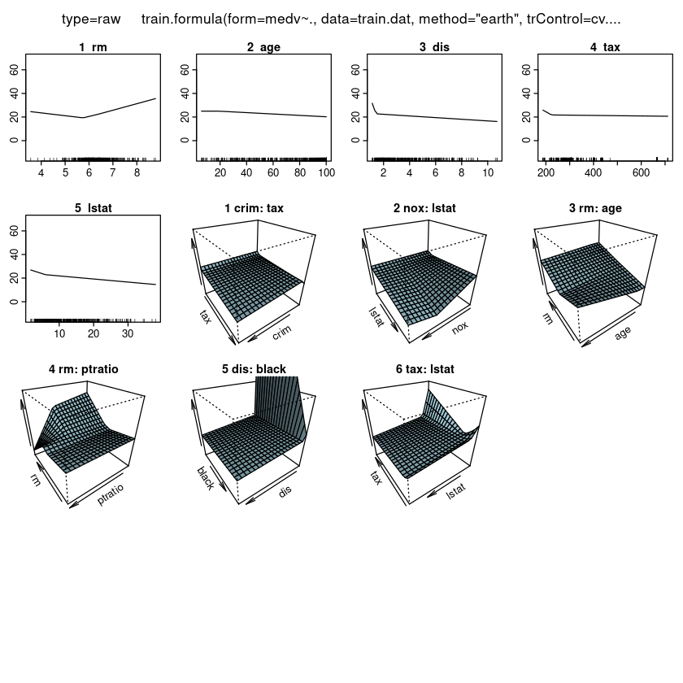

```r
plot(mars.fit)

plotmo(mars.fit, nrug = -1)
```

3.66868831305303

A matrix: 1 × 1 of type dbl

| y | 0.8409446 |
| --- | --- |

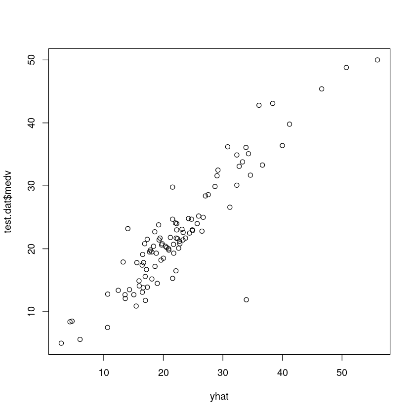

```r
#Make prediction on the testing data

yhat = predict(mars.fit, test.dat)

plot(yhat, test.dat$medv)

#RMSE on the testing data of the fitted model
caret::RMSE(test.dat$medv, yhat)

caret::R2(test.dat$medv, yhat)
```

```
Call: earth(x=matrix[407,13], y=c(21.6,34.7,33...), keepxy=TRUE, degree=3,
            nprune=12)

                              coefficients
(Intercept)                       28.46807
h(6.417-rm)                       -5.99140
h(rm-6.417)                       11.56889
h(age-18.8)                       -0.07108
h(1.4165-dis)                    762.73161
h(dis-1.4165)                     -0.67579
h(1.4165-dis) * black             -1.86997
h(5.757-rm) * h(age-18.8)          0.12796
h(rm-6.417) * h(ptratio-18.4)     -7.17988
h(284-tax) * h(5.98-lstat)         0.04178
h(tax-284) * h(5.98-lstat)         0.02219
h(tax-330) * h(lstat-5.98)        -0.00166

Selected 12 of 26 terms, and 7 of 13 predictors (nprune=12)
Termination condition: Reached nk 27
Importance: rm, lstat, dis, tax, ptratio, black, age, crim-unused, ...
Number of terms at each degree of interaction: 1 5 6
GCV 10.13995    RSS 3569.218    GRSq 0.8818489    RSq 0.8973125
```

```
 plotmo grid:    crim zn indus chas   nox    rm  age    dis rad tax ptratio
               0.2498  0  9.69    0 0.538 6.208 77.8 3.1323   5 330    19.1
  black lstat
 391.83 11.34
```

[output not shown]

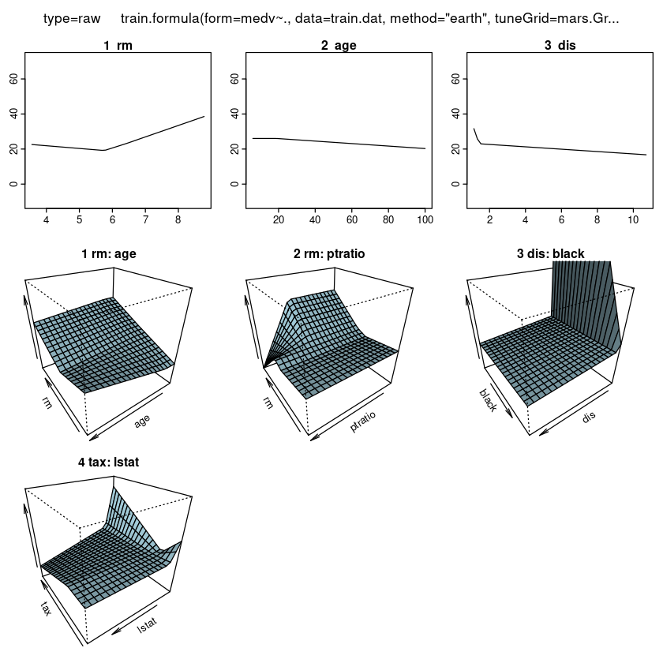

```r
# Train the MARS model , to find the optimal tuning parametesr
# Two hypparameters:   the maximum degree of interactions, and the number of terms in the final model

#To have the same results every time
set.seed(295)

ctrl = trainControl(method = "cv", number = 5)

#two hyper-parameters: the maximum degree of interactions, and the number of terms in the final model
mars.Grid = expand.grid(degree = 1:4, nprune = 2:100)

#Trains multiple MARS models with different parameter combinations.
#Evaluates each using cross-validation.
#Selects the best model based on performance metrics
mars.fit = train( medv ~ ., data = train.dat,
                  method = "earth",
                  tuneGrid = mars.Grid,
                  trControl = ctrl)
summary(mars.fit)

#partial plot
#Generates partial dependence plots (PDPs) for the fitted MARS model.Each plot shows how the predicted response changes as one predictor varies, keeping others fixed.Useful for visualizing nonlinear effects and interactions captured by the model.
plotmo(mars.fit)
```

```r
mars.fit$finalModel
```

```
Selected 12 of 26 terms, and 7 of 13 predictors (nprune=12)
Termination condition: Reached nk 27
Importance: rm, lstat, dis, tax, ptratio, black, age, crim-unused, ...
Number of terms at each degree of interaction: 1 5 6
GCV 10.13995    RSS 3569.218    GRSq 0.8818489    RSq 0.8973125
```

The grid specifies two key hyperparameters:

1. `degree`
- Defines the **maximum degree of interactions** allowed in the model.
- **`degree = 1`**: includes only **main effects** (no interaction terms).
- **`degree = 2`**: allows **two-way interactions**, and so on up to **`degree = 4`**.
2. `nprune`
- Specifies the **number of terms (basis functions)** to include in the **final pruned model**.
- MARS begins by constructing a large model and then **prunes it** to prevent overfitting.

#### Grid Range

The model is tuned over the following parameter ranges:

- `degree`: from **1 to 4**
- `nprune`: from **2 to 100**

Hence, the grid explores a total of
$$4 \times 99 = 396$$
possible combinations of hyperparameters.

The figure displays the **partial dependence plots (PDPs)** and **interaction surface plots** for the model predicting median house value (`medv`) from the Boston housing dataset. The **top row** shows the main effects of individual predictors, while the **bottom rows** illustrate how pairs of predictors interact. The first three 1D plots indicate that `medv` increases with the average number of rooms (`rm`), slightly decreases with the proportion of older homes (`age`), and drops sharply with greater distance from employment centers (`dis`). These nonlinear relationships suggest that more rooms and proximity to job centers increase housing values, while older housing areas reduce them. The 3D surface plots reveal several important interactions. The combination of **`rm` and `age`** shows that newer homes with more rooms have the highest predicted values. The **`rm` and `ptratio`** interaction indicates that houses with more rooms and lower pupil-teacher ratios (better schools) are more valuable. The **`dis` and `black`** interaction reflects how neighborhood composition modifies the effect of distance on housing values. Finally, the **`tax` and `lstat`** interaction shows that areas with higher tax rates and higher proportions of low-status residents have the lowest predicted house values. Overall, these plots demonstrate that the MARS model captures complex **nonlinear** and **interactive** relationships that linear models would miss.

```r
#The final model selected
mars.fit$finalModel

mars.fit$bestTune

coef(mars.fit$finalModel)
```

```
Selected 12 of 26 terms, and 7 of 13 predictors (nprune=12)
Termination condition: Reached nk 27
Importance: rm, lstat, dis, tax, ptratio, black, age, crim-unused, ...
Number of terms at each degree of interaction: 1 5 6
GCV 10.13995    RSS 3569.218    GRSq 0.8818489    RSq 0.8973125
```

A data.frame: 1 × 2

|  | nprune <int> | degree <int> |
| --- | --- | --- |
| 209 | 12 | 3 |

**(Intercept)**

28.4680683974249

**h(rm-6.417)**

11.5688920877369

**h(6.417-rm)**

-5.99139893795382

**h(rm-6.417) * h(ptratio-18.4)**

-7.17988162003179

**h(tax-284) * h(5.98-lstat)**

0.0221902280917752

**h(284-tax) * h(5.98-lstat)**

0.0417787338058719

**h(tax-330) * h(lstat-5.98)**

-0.00166156531119545

**h(dis-1.4165)**

-0.675794453274788

**h(1.4165-dis)**

762.731611460782

**h(1.4165-dis) * black**

-1.86997067311986

**h(age-18.8)**

-0.0710779358259277

**h(5.757-rm) * h(age-18.8)**

0.127958838291975

A data.frame: 1 × 8

| degree <int> | nprune <int> | RMSE <dbl> | Rsquared <dbl> | MAE <dbl> | RMSESD <dbl> | RsquaredSD <dbl> | MAESD <dbl> |
| --- | --- | --- | --- | --- | --- | --- | --- |
| 3 | 12 | 3.509828 | 0.8597695 | 2.505702 | 0.4548542 | 0.02810607 | 0.2093158 |

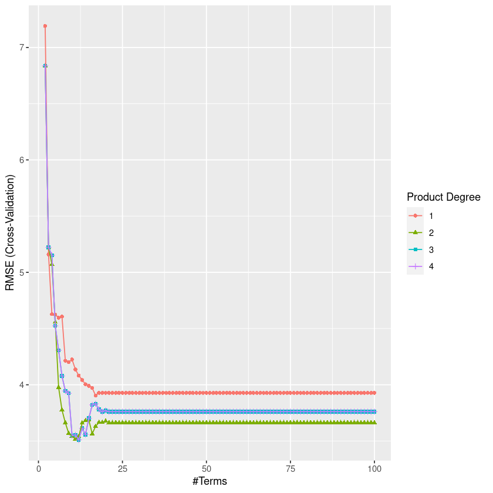

```r
#to extract the performance metrics corresponding to the best-tuned MARS model from the cross-validation results stored in mars.fit
mars.fit$results %>%
  filter(nprune == mars.fit$bestTune$nprune, degree == mars.fit$bestTune$degree)

#To provide a visual diagnostic of how the MARS model’s accuracy changes with varying model complexity, and to confirm that the selected hyperparameters
ggplot(mars.fit)
```

Excerise: The "concrete" dataset (from the AppliedPredictiveModeling package) contains measurements of ingredient proportions used to make concrete and the resulting CompressiveStrength.

Reproducibility: set seed = 53289.

Data split: create a training/test split (e.g., 80/20). Scaling: apply min_max scaling before build the predecitive model.

Use the earth (MARS) or the train function in caret package to build a MARs model that predicts CompressiveStrength using all other features in the Concrete dataset.

a). Find the best tuning parameters using train function on the training set. Use the grid via mars.Grid = expand.grid(degree = 1:2, nprune = 2:30). For cross validation, please use k folds CV with k = 6.

b). Plot the partial effects of each predictor. Intepret the results.

c). use the model to predict the CompressiveStrength on the testing data. Find RMSE, R2.

```r
library(AppliedPredictiveModeling)

data(concrete)

head(concrete)

#Please use 'earth' to build a MARS model to predict 'CompressiveStrength'
```

A data.frame: 6 × 9

|  | Cement <dbl> | BlastFurnaceSlag <dbl> | FlyAsh <dbl> | Water <dbl> | Superplasticizer <dbl> | CoarseAggregate <dbl> | FineAggregate <dbl> | Age <int> | CompressiveStrength <dbl> |
| --- | --- | --- | --- | --- | --- | --- | --- | --- | --- |
| 1 | 540.0 | 0.0 | 0 | 162 | 2.5 | 1040.0 | 676.0 | 28 | 79.99 |
| 2 | 540.0 | 0.0 | 0 | 162 | 2.5 | 1055.0 | 676.0 | 28 | 61.89 |
| 3 | 332.5 | 142.5 | 0 | 228 | 0.0 | 932.0 | 594.0 | 270 | 40.27 |
| 4 | 332.5 | 142.5 | 0 | 228 | 0.0 | 932.0 | 594.0 | 365 | 41.05 |
| 5 | 198.6 | 132.4 | 0 | 192 | 0.0 | 978.4 | 825.5 | 360 | 44.30 |
| 6 | 266.0 | 114.0 | 0 | 228 | 0.0 | 932.0 | 670.0 | 90 | 47.03 |

```r
dat = concrete

set.seed(53289)

index = createDataPartition(dat$CompressiveStrength, p = 0.8, list = FALSE)
train.dat = dat[index,]
test.dat =   dat[-index,]
```

```
Call: earth(x=matrix[826,8], y=c(61.89,40.27,4...), keepxy=TRUE, degree=1,
            nprune=18)

                         coefficients
(Intercept)                169.794206
h(236-Cement)               -0.137173
h(Cement-236)                0.104654
h(53.8-BlastFurnaceSlag)    -0.140371
h(BlastFurnaceSlag-53.8)     0.065049
h(174.2-FlyAsh)             -0.048381
h(FlyAsh-174.2)             -0.427055
h(Water-137.8)              -1.020070
h(219.7-Water)              -0.756285
h(Water-219.7)               1.521478
h(11.4-Superplasticizer)    -0.225270
h(Superplasticizer-11.4)    -0.664656
h(655-FineAggregate)        -0.235014
h(FineAggregate-655)        -0.228504
h(FineAggregate-689)         0.236244
h(Age-14)                   -0.897361
h(56-Age)                   -1.256750
h(Age-56)                    0.907370

Selected 18 of 18 terms, and 7 of 8 predictors (nprune=18)
Termination condition: Reached nk 21
Importance: Age, Cement, Water, BlastFurnaceSlag, FlyAsh, Superplasticizer, ...
Number of terms at each degree of interaction: 1 17 (additive model)
GCV 37.97637    RSS 28766.46    GRSq 0.8619793    RSq 0.8731212
```

```
 plotmo grid:    Cement BlastFurnaceSlag FlyAsh Water Superplasticizer
                    266               24      0 185.7              6.4
 CoarseAggregate FineAggregate Age
             968           778  28
```

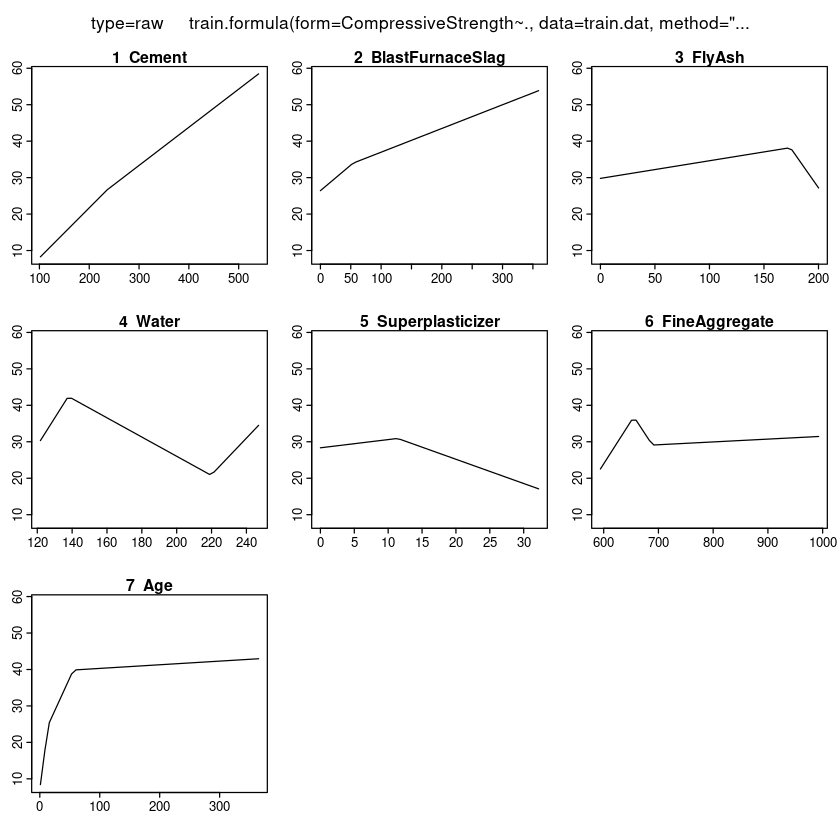

```r
ctrl = trainControl(method = "cv", number = 6)

#two hyper-parameters: the maximum degree of interactions, and the number of terms in the final model
mars.Grid = expand.grid(degree = 1:2, nprune = 2:30)

#Trains multiple MARS models with different parameter combinations.
#Evaluates each using cross-validation.
#Selects the best model based on performance metrics
mars.fit = train( CompressiveStrength ~ ., data = train.dat,
                  method = "earth",
                  tuneGrid = mars.Grid,
                  trControl = ctrl)
summary(mars.fit)

#partial plot
#Generates partial dependence plots (PDPs) for the fitted MARS model.Each plot shows how the predicted response changes as one predictor varies, keeping others fixed.Useful for visualizing nonlinear effects and interactions captured by the model.
plotmo(mars.fit)
```

6.7833842515617

A matrix: 1 × 1 of type dbl

| y | 0.8448087 |
| --- | --- |

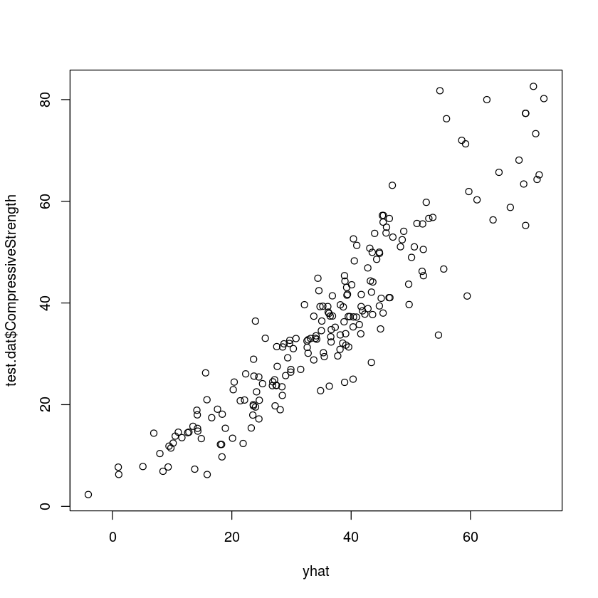

```r
yhat = predict(mars.fit, test.dat)

plot(yhat, test.dat$CompressiveStrength)

#RMSE on the testing data of the fitted model
caret::RMSE(test.dat$CompressiveStrength, yhat)

caret::R2(test.dat$CompressiveStrength, yhat)
```